# Tarea Machine Learning en el Projecto MONICA de la OMS

2019-09-09

**Profesor**: Javier Portela

**Alumno**: Beatriz González García

## **1.- INTRODUCCIÓN**

El proyecto [MONICA](https://www.thl.fi/monica/) (Multinational **MONI**toring of Trends and Determinants in **CA**rdiovascular Disease) de la OMS se diseñó en los años 1980 para estudiar las tendencias y determinantes en las enfermedades cardiovasculares. Se llevó a cabo en 32 centros de 21 países, recogiendo datos de 10 millones de individuos de ambos sexos con edades comprendidas entre 25 y 64 años.

## **2.- DATOS UTILIZADOS**

Este análisis está basado en el dataset [monica](https://vincentarelbundock.github.io/Rdatasets/datasets.html). El objetivo es predecir la variable **Outcome**, binaria que mide el resultado de mortalidad como un factor con dos niveles live o dead. Para la realización de esta tarea se ha usado el paquete R.

[figure not shown]

## **3.- ESTUDIO DEL DATASET**

Es un archivo en formato csv.

```r
monica <- read.csv("monica.csv",header=TRUE,sep = ",")
```

Hacemos un primer análisis exploratorio

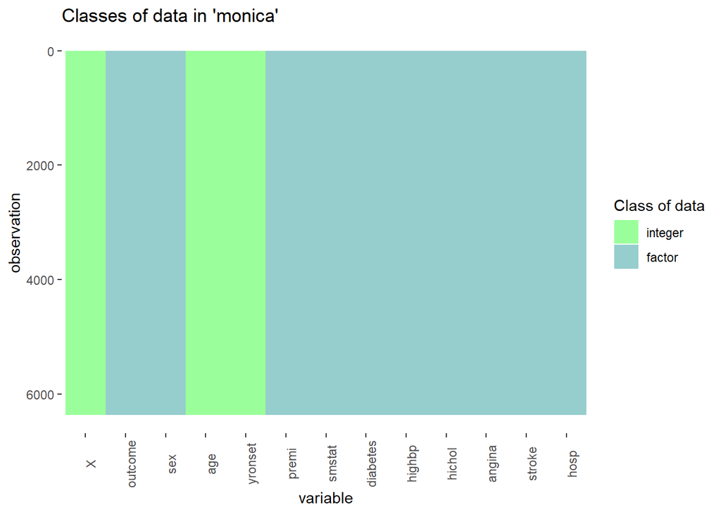

Cambiamos el nombre de las variables.

```r
names(monica)
```

```
##  [1] "X"        "outcome"  "sex"      "age"      "yronset"  "premi"
##  [7] "smstat"   "diabetes" "highbp"   "hichol"   "angina"   "stroke"
## [13] "hosp"
```

```r
names (monica) = c("X", "Mortalidad", "Sexo", "Edad", "Year",
                   "Infarto","Fumador", "Diabetes",
                   "Tension","Colesterol","Angina",
                   "Accidente","Hospitalizacion")
```

El conjunto de datos está formado por 6.367 observaciones y 13 variables.

Dentro de estas variables dos son cuantitativas y el resto cualitativas.

De las 13 variables **X** corresponde al número secuencial que identifica la observación por lo que en realidad son 12 variables efectivas.

Son las siguientes:

- *Sexo* - Sexo
- *Edad* - Edad
- *Year* - Año en que se tomó el dato
- *Infarto* - Infarto de miocardio previo, un factor con los niveles y(yes), n(not) y nk (not known)
- *Fumador* - Status de fumador, un factor con los niveles c(Fumador), x(Exfumador), n(Nofumador) y nk (not known)
- *Diabetes* - Un factor con los niveles y(yes), n(not) y nk (not known)
- *Tension* - Presión arterial alta, un factor con los niveles y(yes), n(not) y nk (not known)
- *Colesterol* - Colesterol alto, un factor con los niveles y(yes), n(not) y nk (not known)
- *Angina* - Angina de pecho previa, un factor con los niveles y(yes), n(not) y nk (not known)
- *Accidente* - Accidente cerebrovascular, un factor con los niveles y(yes), n(not) y nk (not known)
- *Hospitalizacion* - Hospitalización después de sufrir el infarto, un factor con los niveles y(yes) y n(not)

La variable objetivo es Mortalidad que toma dos posibles valores

- *live* - Supervivencia a un infarto
- *dead* - Muerte después de un infarto

Recodificamos algunas variables para que sea más sencillo el estudio de los datos. Para ello utilizamos la función recode de la librería car.

```r
              monica$Sexo <- car::recode(monica$Sexo,
                                         "c('f')='Mujer';
                                          c('m')='Hombre'")
           monica$Infarto <- car::recode(monica$Infarto,
                                         "c('y')='Si';
                                          c('n')='No'")
           monica$Fumador <- car::recode(monica$Fumador,
                                         "c('c')='Habitual';
                                          c('x')='Exfumador';
                                          c('n')='Nofumador'")
          monica$Diabetes <- car::recode(monica$Diabetes,
                                         "c('y')='Si';
                                          c('n')='No'")
           monica$Tension <- car::recode(monica$Tension,
                                         "c('y')='Si';
                                          c('n')='No'")
        monica$Colesterol <- car::recode(monica$Colesterol,
                                         "c('y')='Si';
                                          c('n')='No'")
            monica$Angina <- car::recode(monica$Angina,
                                         "c('y')='Si';
                                          c('n')='No'")
         monica$Accidente <- car::recode(monica$Accidente,
                                         "c('y')='Si';
                                          c('n')='No'")
   monica$Hospitalizacion <- car::recode(monica$Hospitalizacion,
                                         "c('y')='Si';
                                          c('n')='No'")
```

Vemos las primeras observaciones

```r
head(monica)
```

```
##   X Mortalidad   Sexo Edad Year Infarto   Fumador Diabetes Tension
## 1 1       live  Mujer   63   85      No Exfumador       No      Si
## 2 2       live Hombre   59   85      Si Exfumador       No      Si
## 3 3       live Hombre   68   85      No Nofumador       No      Si
## 4 4       live Hombre   46   85      No  Habitual       No      No
## 5 5       dead Hombre   48   85      No Nofumador       Si      No
## 6 6       live  Mujer   55   85      No  Habitual       No      Si
##   Colesterol Angina Accidente Hospitalizacion
## 1         Si     No        No              Si
## 2         No     No        No              Si
## 3         No     No        No              Si
## 4         No     No        No              Si
## 5         No     Si        No              Si
## 6         Si     No        No              Si
```

Un resumen de los datos

```r
summary(monica)
```

```
##        X        Mortalidad      Sexo           Edad            Year
##  Min.   :   1   dead:2842   Hombre:4605   Min.   :35.00   Min.   :85.00
##  1st Qu.:1592   live:3525   Mujer :1762   1st Qu.:55.00   1st Qu.:87.00
##  Median :3184                             Median :61.00   Median :89.00
##  Mean   :3184                             Mean   :59.42   Mean   :88.75
##  3rd Qu.:4776                             3rd Qu.:66.00   3rd Qu.:91.00
##  Max.   :6367                             Max.   :69.00   Max.   :93.00
##  Infarto        Fumador     Diabetes  Tension   Colesterol Angina
##  nk: 734   Exfumador:1938   nk: 885   nk: 948   nk:1233    nk: 975
##  No:4122   Habitual :2051   No:4664   No:2542   No:3294    No:3473
##  Si:1511   nk       : 918   Si: 818   Si:2877   Si:1840    Si:1919
##            Nofumador:1460
##
##
##  Accidente Hospitalizacion
##  nk: 926   No:1925
##  No:4881   Si:4442
##  Si: 560
##
##
##
```

Y la tipología de las variables

```r
str(monica)
```

```
## 'data.frame':    6367 obs. of  13 variables:
##  $ X              : int  1 2 3 4 5 6 7 8 9 10 ...
##  $ Mortalidad     : Factor w/ 2 levels "dead","live": 2 2 2 2 1 2 2 2 2 2 ...
##  $ Sexo           : Factor w/ 2 levels "Hombre","Mujer": 2 1 1 1 1 2 1 2 1 2 ...
##  $ Edad           : int  63 59 68 46 48 55 56 68 69 64 ...
##  $ Year           : int  85 85 85 85 85 85 85 85 85 85 ...
##  $ Infarto        : Factor w/ 3 levels "nk","No","Si": 2 3 2 2 2 2 2 3 2 2 ...
##  $ Fumador        : Factor w/ 4 levels "Exfumador","Habitual",..: 1 1 4 2 4 2 1 3 4 1 ...
##  $ Diabetes       : Factor w/ 3 levels "nk","No","Si": 2 2 2 2 3 2 2 1 2 2 ...
##  $ Tension        : Factor w/ 3 levels "nk","No","Si": 3 3 3 2 2 3 3 3 3 3 ...
##  $ Colesterol     : Factor w/ 3 levels "nk","No","Si": 3 2 2 2 2 3 2 1 3 2 ...
##  $ Angina         : Factor w/ 3 levels "nk","No","Si": 2 2 2 2 3 2 2 3 2 3 ...
##  $ Accidente      : Factor w/ 3 levels "nk","No","Si": 2 2 2 2 2 2 2 2 2 2 ...
##  $ Hospitalizacion: Factor w/ 2 levels "No","Si": 2 2 2 2 2 2 2 2 2 2 ...
```

Contamos para las variables numéricas el número de valores diferentes:

```r
sapply(Filter(is.numeric, monica),function(x) length(unique(x)))
```

```
##    X Edad Year
## 6367   35    9
```

La variable Year se puede convertir en factor porque sólo tiene nueve categorías

```r
# convertimos en factor la variable Year que sólo tiene nueve categorías

monica$Year <- factor(monica$Year)
```

### **3.1.- Tratamiento Missings**

En este archivo hay muchas variables que presentan el valor nk(not know) estas variables son missings y por eso las recodificamos como NA.

Utilizamos la función recode del paquete questionr

```r
           monica$Infarto <- questionr::recode.na(monica$Infarto,"nk")
           monica$Fumador <- questionr::recode.na(monica$Fumador,"nk")
          monica$Diabetes <- questionr::recode.na(monica$Diabetes,"nk")
           monica$Tension <- questionr::recode.na(monica$Tension,"nk")
        monica$Colesterol <- questionr::recode.na(monica$Colesterol,"nk")
            monica$Angina <- questionr::recode.na(monica$Angina,"nk")
         monica$Accidente <- questionr::recode.na(monica$Accidente,"nk")
```

Vemos si hay algún patrón en la proporción de missings

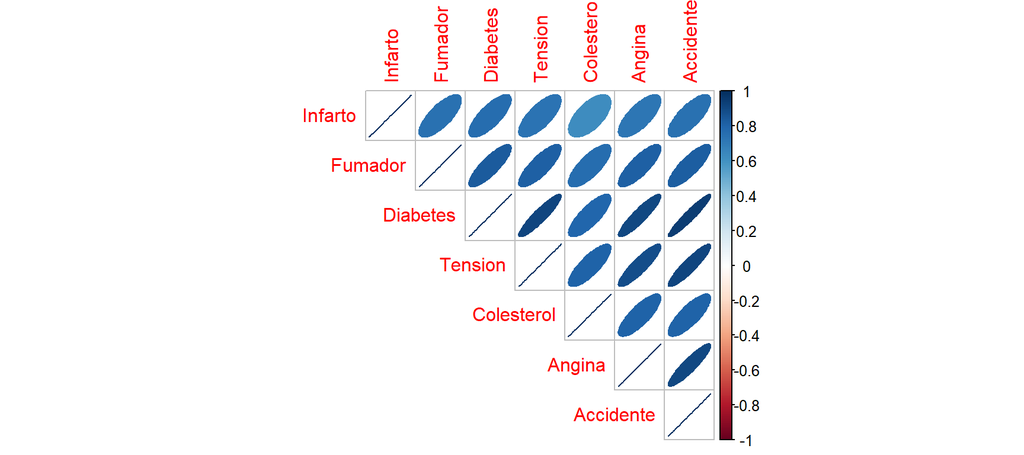

```r
corrplot(cor(is.na(monica[colnames(monica)[colSums(is.na(monica))>0]])),method = "ellipse",type = "upper")
```

Se observa que hay observaciones en las que la mayoría de los valores son missings

Incorporamos en cada fila su proporción de missings para posteriormente poder seleccionar las observaciones con menor número de missings:

```r
monica$prop_missings<-apply(is.na(monica),1,mean)
```

Por otro lada también vemos la proporción de missings por variable

```r
# Vemos la proporcion de missings por variable
(prop_missingsVars<-apply(is.na(monica),2,mean))
```

```
##               X      Mortalidad            Sexo            Edad
##       0.0000000       0.0000000       0.0000000       0.0000000
##            Year         Infarto         Fumador        Diabetes
##       0.0000000       0.1152819       0.1441809       0.1389980
##         Tension      Colesterol          Angina       Accidente
##       0.1488927       0.1936548       0.1531333       0.1454374
## Hospitalizacion   prop_missings
##       0.0000000       0.0000000
```

No hay variables con más del 50% de missings.

Seleccionamos del conjunto de datos aquellas observaciones con menos del 50 % de missings:

```r
input <- subset(monica, prop_missings< 0.5)#Se han eliminado 621 observaciones
```

Utilizamos las funciones de mineria de datos para imputar los NA por un valor aleatorio:

```r
# Aplicamos a todas las variables factor la transformación de los NA a un valor aleatorio
input[,as.vector(which(sapply(input, class) == "factor"))]<- sapply(Filter(is.factor, input),function(x) ImputacionCuali(x,"aleatorio"))

# como esta funciona cambia los factores a character los volvemos a cambiar a factor
input[,as.vector(which(sapply(input, class) == "character"))] <- lapply(input[,as.vector(which(sapply(input, class)=="character"))] , factor)

# Comprobamos que no quedan observaciones con valores missings
summary(input)
```

```
##        X        Mortalidad      Sexo           Edad            Year
##  Min.   :   1   dead:2221   Hombre:4163   Min.   :35.00   87     : 734
##  1st Qu.:1569   live:3525   Mujer :1583   1st Qu.:55.00   85     : 706
##  Median :3104                             Median :61.00   86     : 691
##  Mean   :3156                             Mean   :59.35   90     : 641
##  3rd Qu.:4749                             3rd Qu.:66.00   89     : 640
##  Max.   :6367                             Max.   :69.00   88     : 639
##                                                           (Other):1695
##  Infarto        Fumador     Diabetes  Tension   Colesterol Angina
##  No:4206   Exfumador:2041   No:4883   No:2693   No:3686    No:3710
##  Si:1540   Habitual :2168   Si: 863   Si:3053   Si:2060    Si:2036
##            Nofumador:1537
##
##
##
##
##  Accidente Hospitalizacion prop_missings
##  No:5151   No:1413         Min.   :0.00000
##  Si: 595   Si:4333         1st Qu.:0.00000
##                            Median :0.00000
##                            Mean   :0.03042
##                            3rd Qu.:0.00000
##                            Max.   :0.46154
##
```

Nos quedamos con los datos depurados

```r
# Quitamos el identificador(X) y la proporcíon de missings(14) y guardamos los datos depurados
Monica_Dep <- as.data.frame(input[,-c(1,14)])
```

### **3.2.- Tratamiento Outliers**

En este dataset sólo hay una variable cuantitativa. Y comprobamos que no presenta valores fuera de rango

```r
psych::describe(Filter(is.numeric, monica))
```

[output not shown]

### **3.3.- Relación con la variable objetivo**

Vemos la frecuencia y la relación con la variable objetivo de las distintas variables input:

- **Sexo**: Los hombres sufren más infartos que las mujeres

```
##           n    % val%
## Hombre 4163 72.5 72.5
## Mujer  1583 27.5 27.5
```

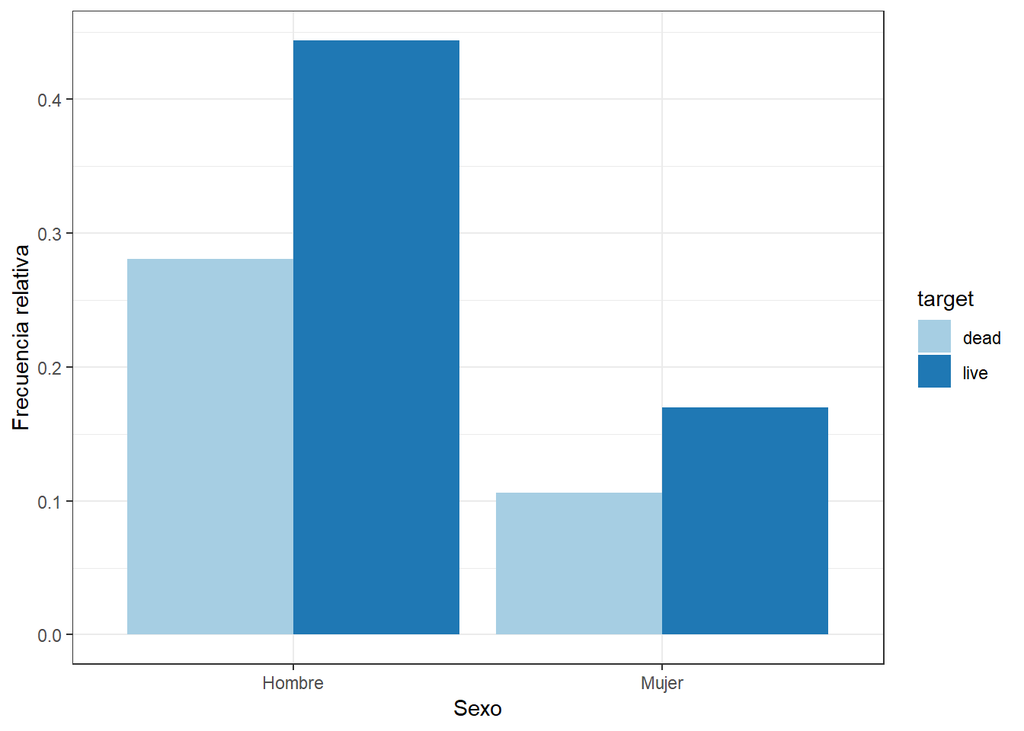

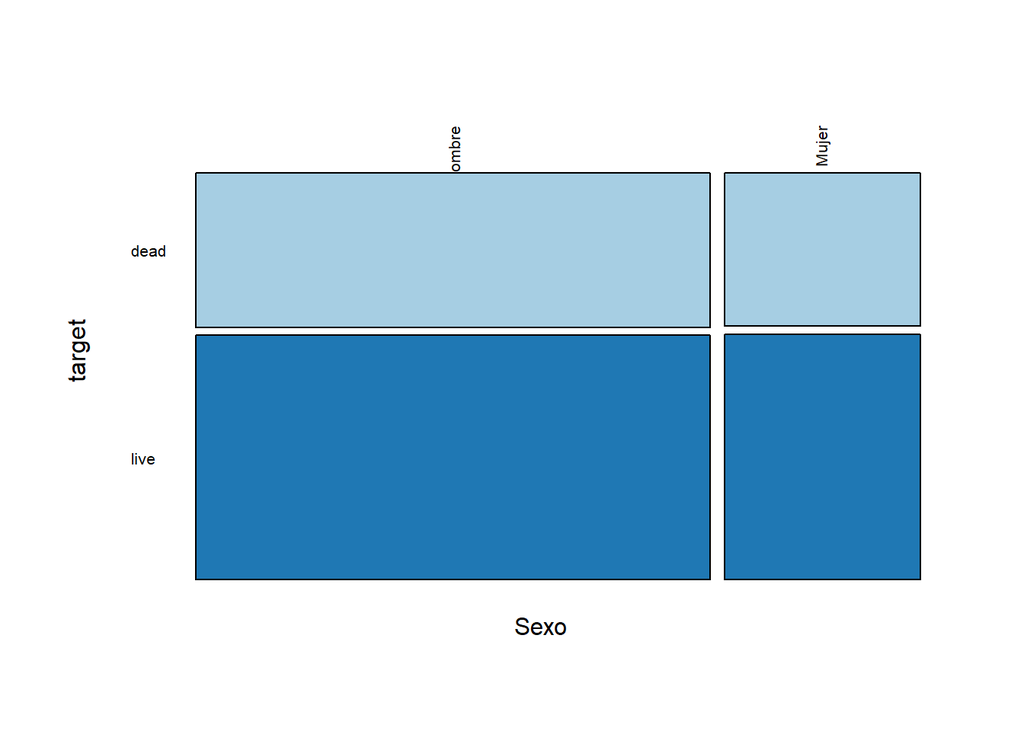

- **Year**: A partir del año 89 han disminuido los infartos y la supervivencia es mayor

```
##      n    % val%
## 85 706 12.3 12.3
## 86 691 12.0 12.0
## 87 734 12.8 12.8
## 88 639 11.1 11.1
## 89 640 11.1 11.1
## 90 641 11.2 11.2
## 91 584 10.2 10.2
## 92 562  9.8  9.8
## 93 549  9.6  9.6
```

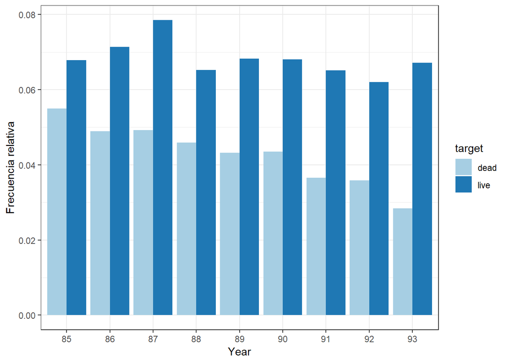

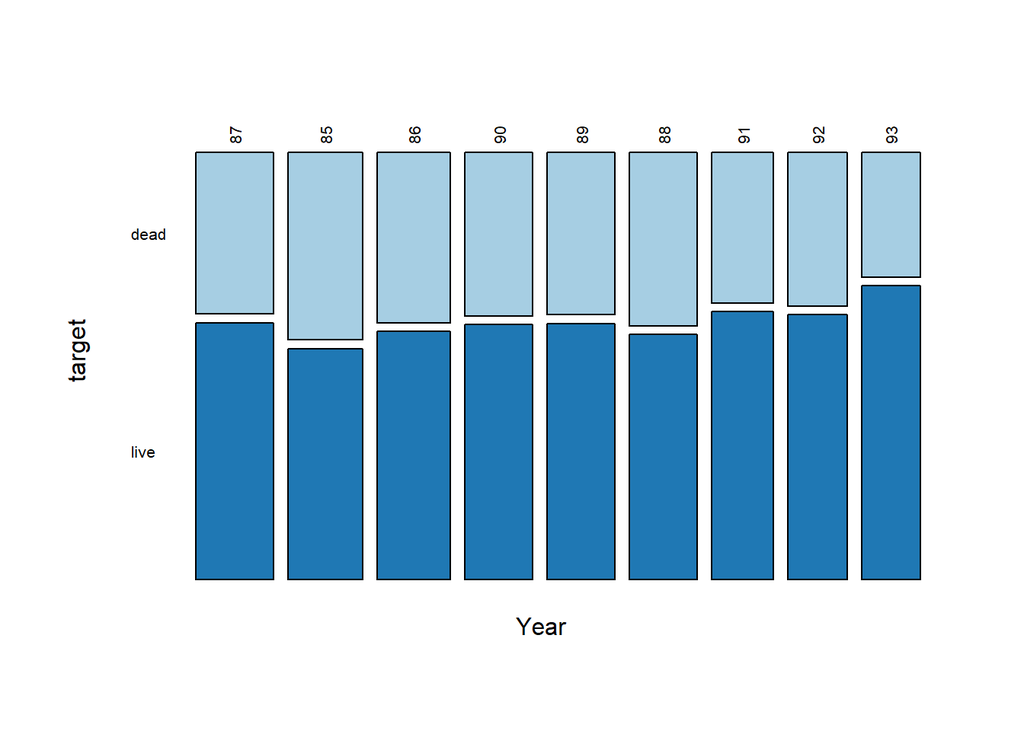

- **Infarto Previo**: En la mayoría de los casos era el primer infarto

```
##       n    % val%
## No 4204 73.2 73.2
## Si 1542 26.8 26.8
```

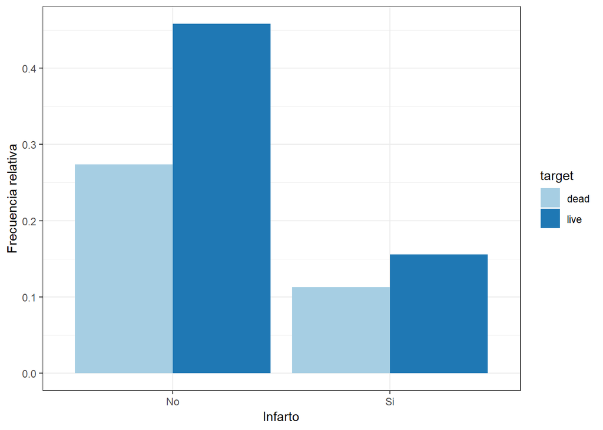

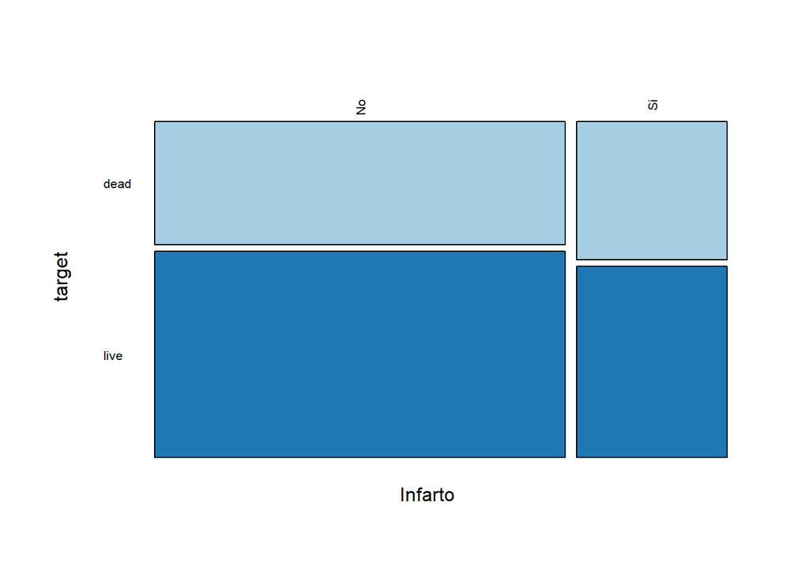

- **Status de fumador**: Los infartos son más frecuentes en fumadores y Exfumadores

```
##              n    % val%
## Exfumador 2048 35.6 35.6
## Habitual  2173 37.8 37.8
## Nofumador 1525 26.5 26.5
```

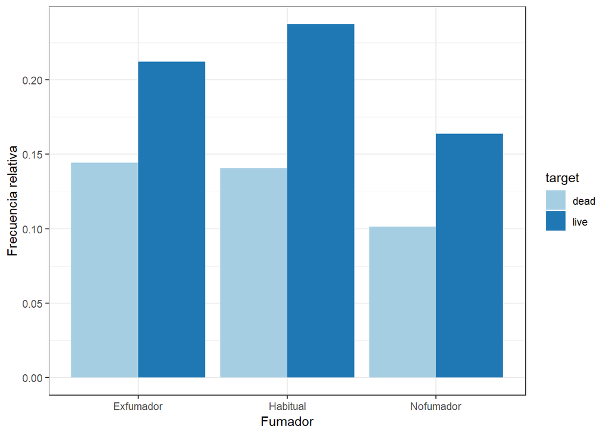

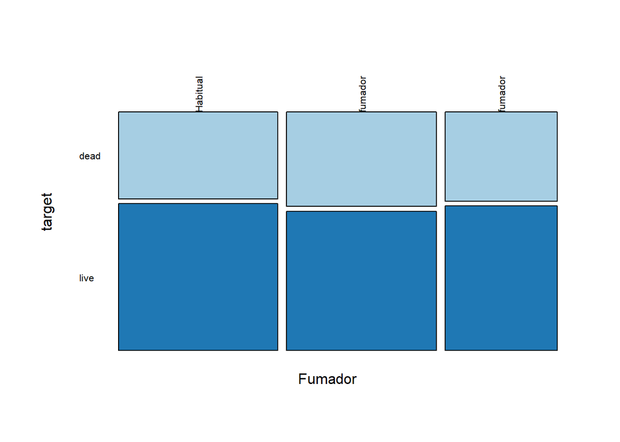

- **Diabetes**: La mayoría de las observaciones corresponden a personas no diabéticas

```
##       n    % val%
## No 4895 85.2 85.2
## Si  851 14.8 14.8
```

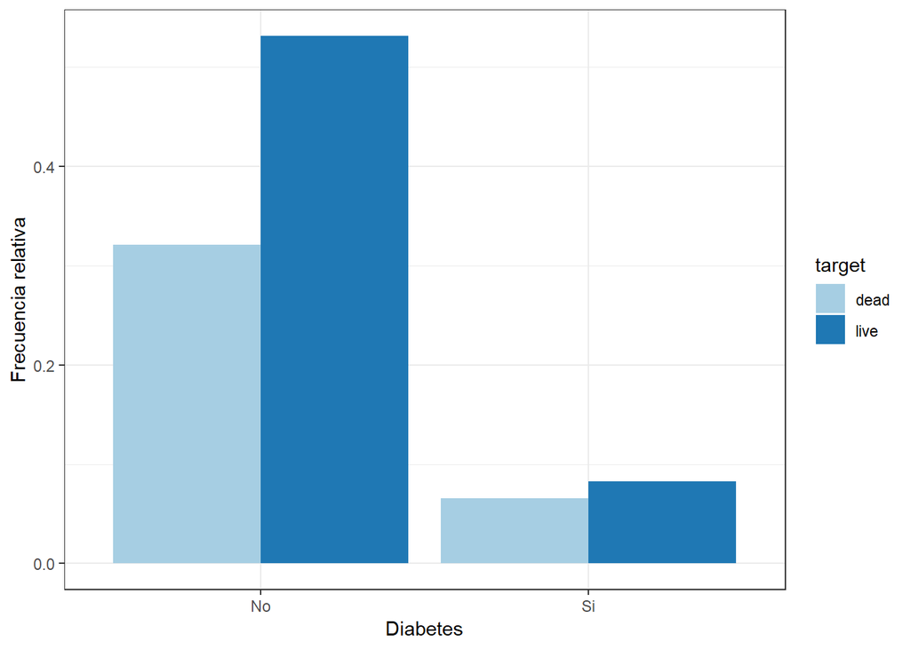

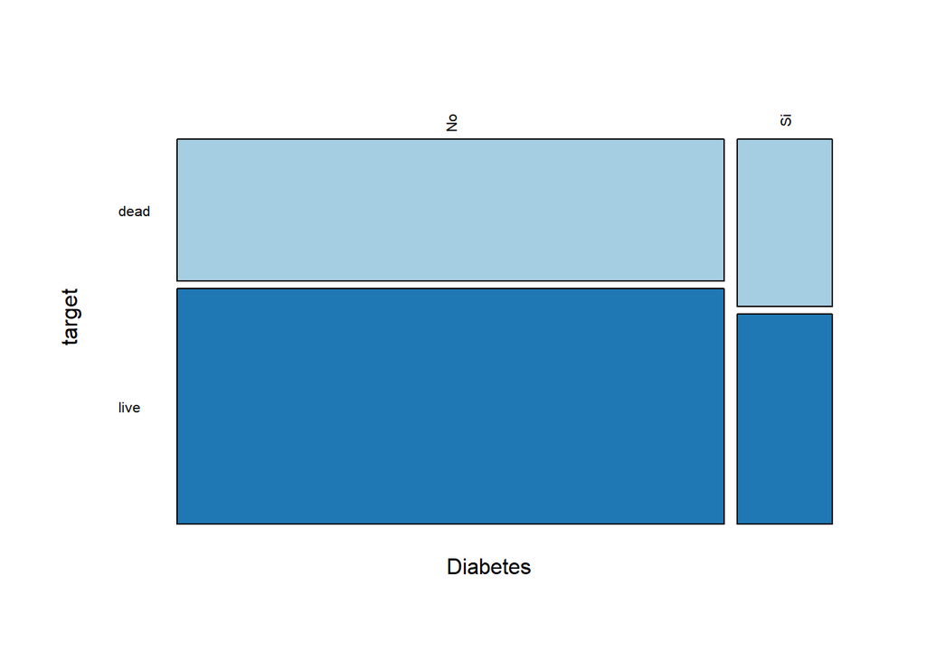

- **Tensión Alta**: La tensión alta es algo común entre las personas que sufren un infarto

```
##       n    % val%
## No 2694 46.9 46.9
## Si 3052 53.1 53.1
```

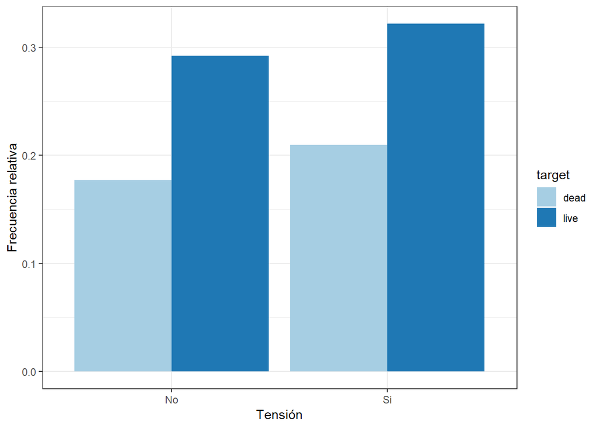

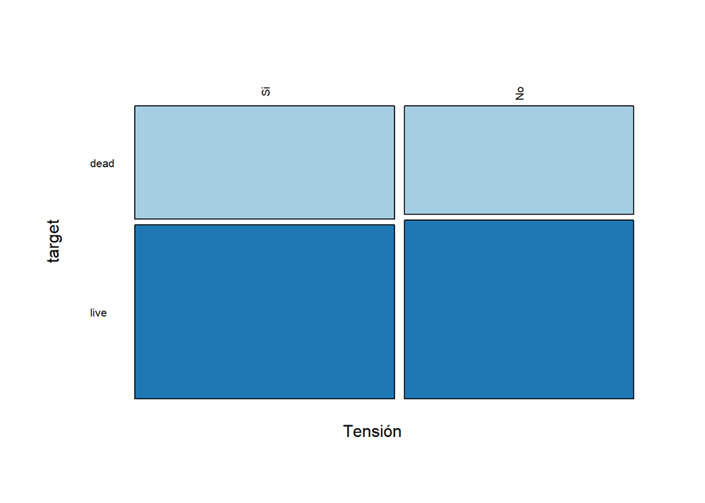

- **Colesterol Alto**: La mayoría de los pacientes no tenían colesterol alto

```
##       n    % val%
## No 3688 64.2 64.2
## Si 2058 35.8 35.8
```

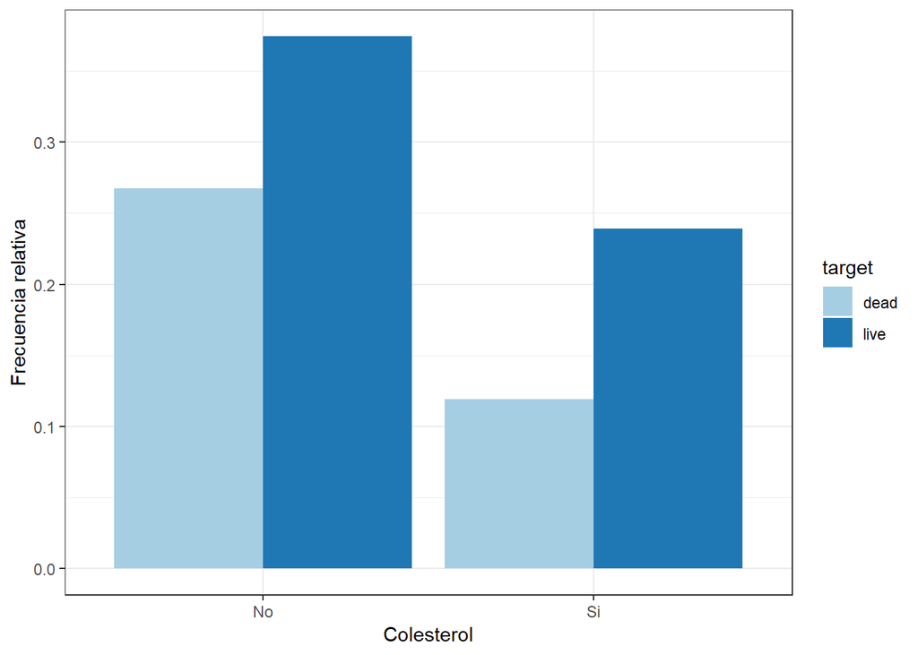

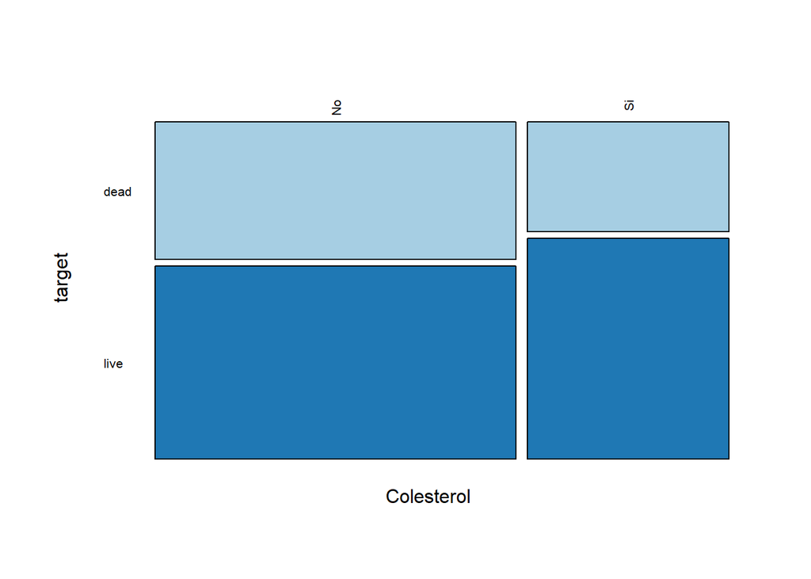

- **Angina de pecho**: Ni habían sufrido una angina de pecho

```
##       n    % val%
## No 3698 64.4 64.4
## Si 2048 35.6 35.6
```

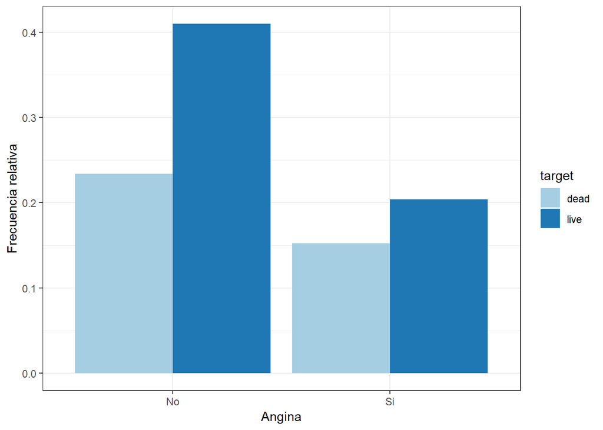

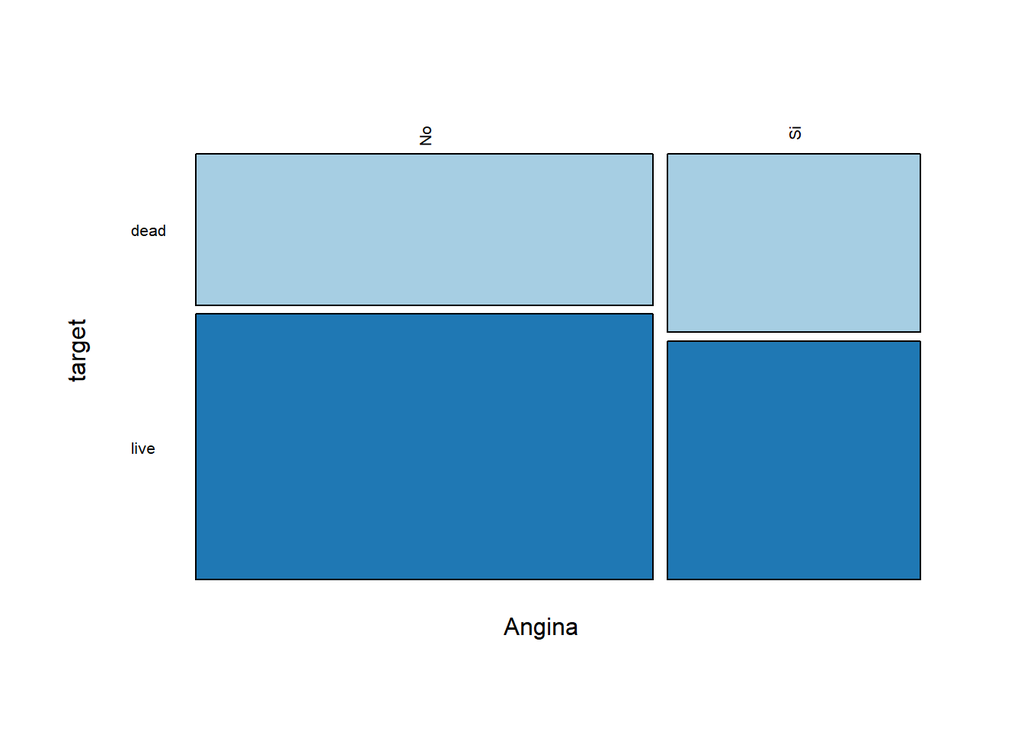

- **Accidente Cerebral**: Ni accidentes cerebrales

```
##       n    % val%
## No 5161 89.8 89.8
## Si  585 10.2 10.2
```

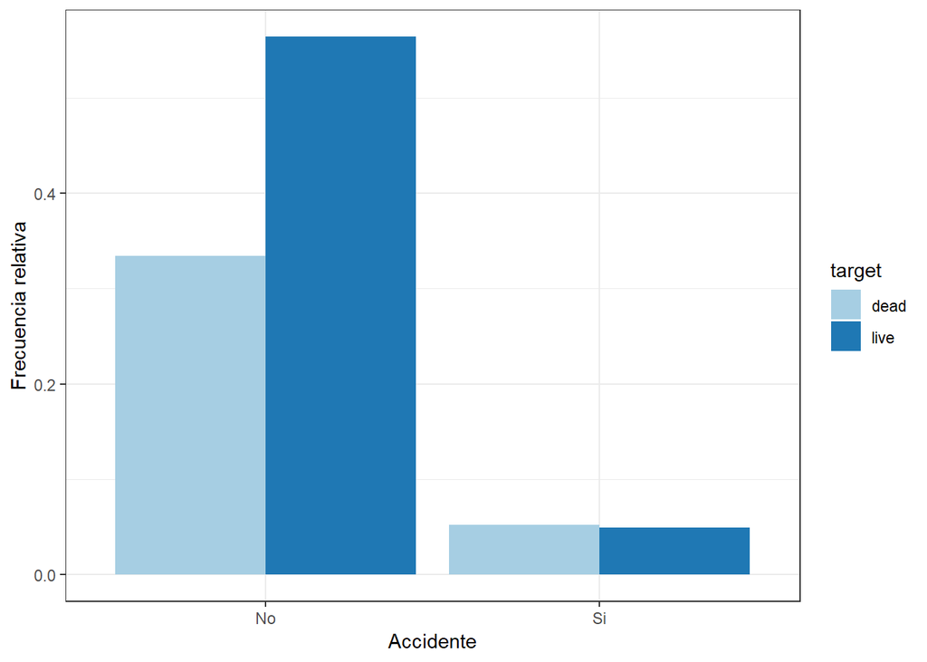

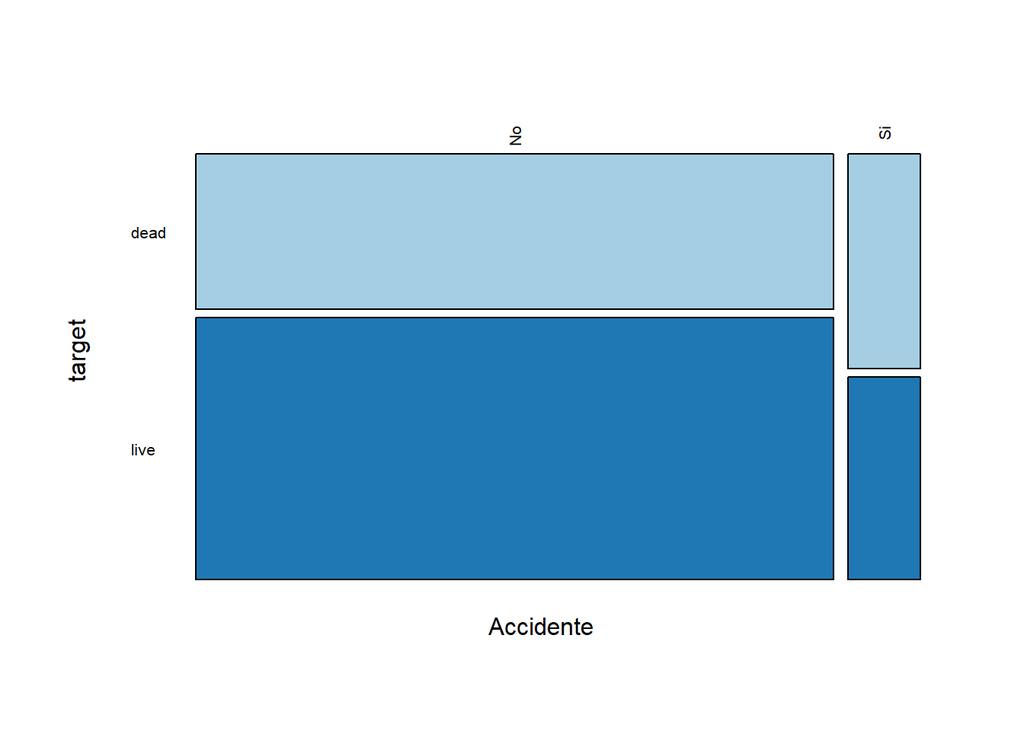

- **Hospitalización**: No se puede superar un infarto sin tratamiento hospitalario

```
##       n    % val%
## No 1413 24.6 24.6
## Si 4333 75.4 75.4
```

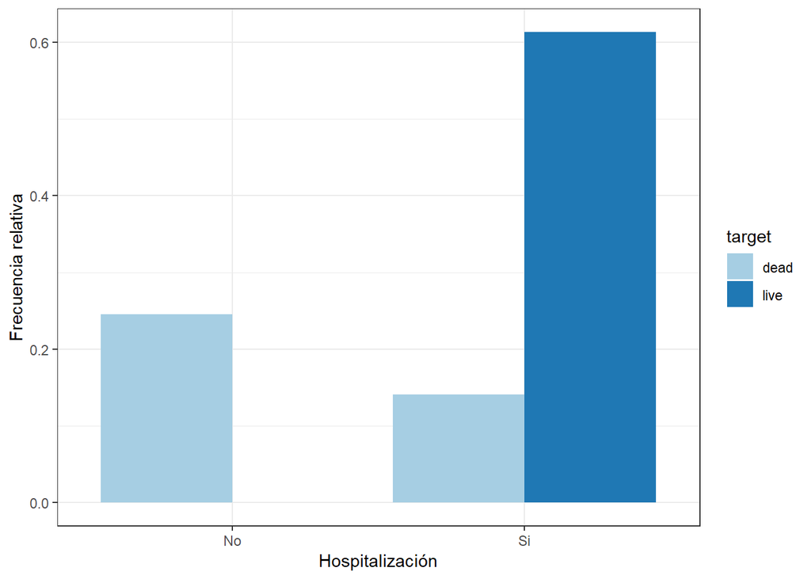

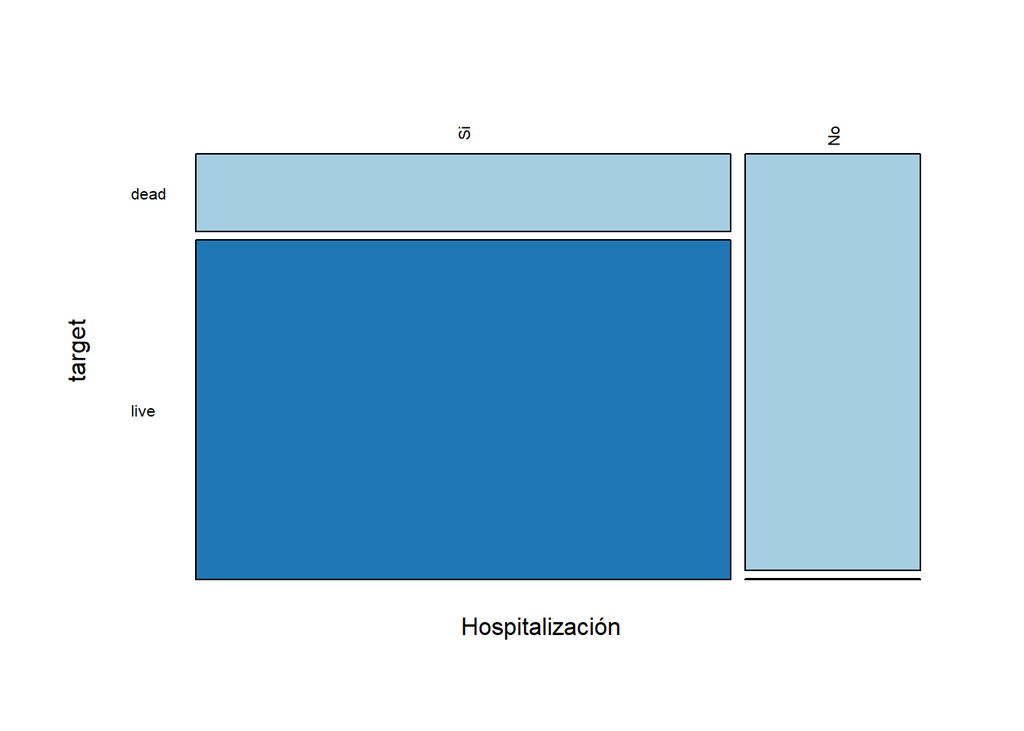

- **Edad**: La edad tiene una efecto negativo en la supervivencia a un infarto

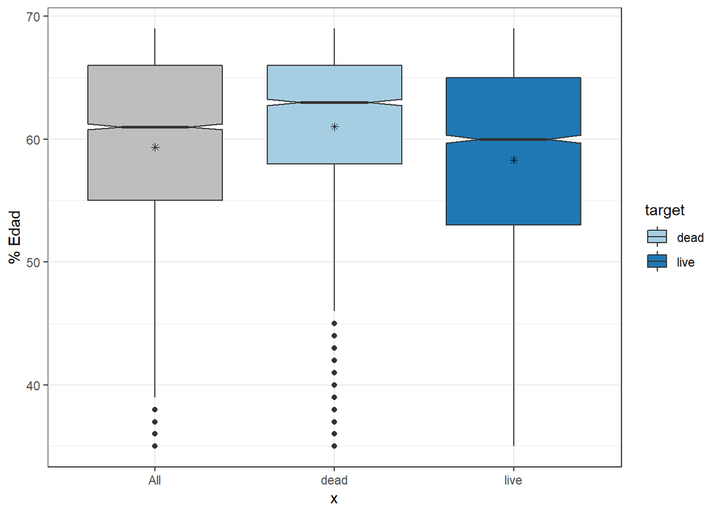

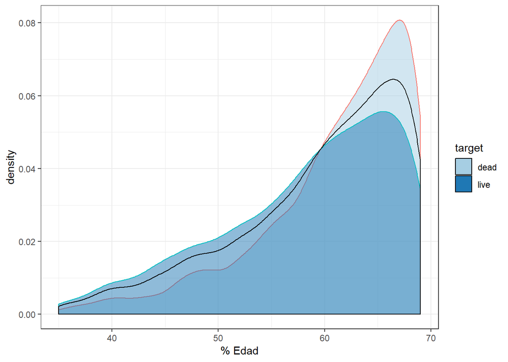

### **3.4.- Selección de variables**

En este apartado hemos usado dos métodos de selección de variables:

- **V de Cramer**: se basa en el estadístico $X^2$. Lo primero que se hace es crear una variable aleatoria que nos permite tener una referencia de la utilidad de las variables.

```r
# Creación de la variable aleatoria
input$aleatorio <- runif(nrow(input))
```

El gráfico que se obtiene es:

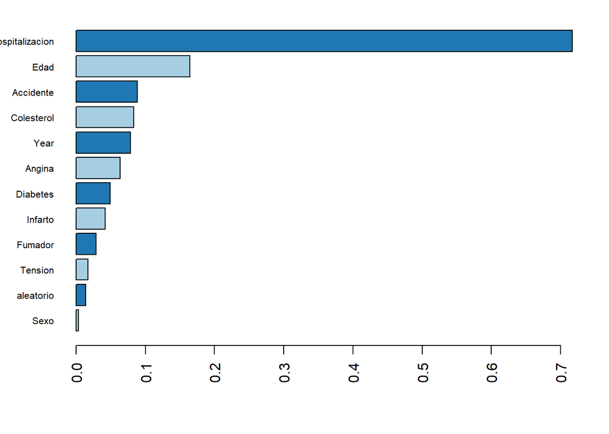

```r
# Para representar la V de Cramer para todas las variables input, usamos la función:
graficoVcramer(input,varObjBin)
```

Según este gráfico las variables que mejor explican la variable objetivo son: Hospitalización, Edad, Accidente Cerebral, Colesterol Alto, Year y Angina. Observamos que hay variables que tienen menos poder explicativo que la propia variable aleatoria, como Sexo.

- **Stepwise o paso a paso**: En cada paso se evaluan las diferentes variables a introducir y a eliminar y se selecciona cual de estas acciones mejora más el modelo. Para calcular la mejora del modelo en este proceso iterativo utilizaremos el criterio de información de Akaike AIC y el criterio de información Bayesiana BIC.

Utilizaremos la funcion steprepetido binaria. Para utlizar esta función previamente hay que estandarizar las variables continuas y las categóricas pasarlas a dummies.

```r
monica$Edad <- as.numeric(monica$Edad)

listconti <- c("Edad")

listclass <- c("Sexo", "Year", "Infarto", "Fumador",
               "Diabetes", "Tension", "Colesterol",
               "Angina", "Accidente","Hospitalizacion")

vardep <- "Mortalidad"

# Transformamos las categóricas a dummies
library(dummies)
monicabis <- dummy.data.frame(monica, listclass, sep = ".")

# Estandarizar la variable continua
monicabis$Edad <- (monicabis$Edad - mean(monicabis$Edad)) / sd(monicabis$Edad)
# Convertir la variable objetivo en Yes/No para que no fallen algoritmos de Machine Learning
monicabis$Mortalidad<-ifelse(monicabis$Mortalidad=="dead","Yes","No")
```

Ahora utilizamos la funcion steprepetidobinaria para el criterio BIC

```r
source("funcion steprepetido binaria.R")
listconti<-c("Sexo.Hombre", "Sexo.Mujer", "Edad", "Year.85",
             "Year.86", "Year.87", "Year.88", "Year.89", "Year.90", "Year.91",
             "Year.92", "Year.93", "Infarto.No", "Infarto.Si",
             "Fumador.Exfumador", "Fumador.Habitual", "Fumador.Nofumador",
             "Diabetes.No", "Diabetes.Si", "Tension.No", "Tension.Si",
             "Colesterol.No", "Colesterol.Si", "Angina.No", "Angina.Si",
             "Accidente.No", "Accidente.Si", "Hospitalizacion.No",
             "Hospitalizacion.Si")
vardep<-c("Mortalidad")

data<-monicabis

lista<-steprepetidobinaria(data=data,
 vardep=vardep,listconti=listconti,sinicio=12345,
 sfinal=12355,porcen=0.8,criterio="BIC")

tabla<-lista[[1]]
variables_BIC <- dput(lista[[2]][[1]])
```

```
## c("Hospitalizacion.No", "Edad", "Angina.No", "Accidente.No",
## "Year.85", "Diabetes.No")
```

Y para el cirterio AIC

```r
lista<-steprepetidobinaria(data=data,
 vardep=vardep,listconti=listconti,sinicio=12345,
 sfinal=12355,porcen=0.8,criterio="AIC")

tabla<-lista[[1]]
variables_AIC <- dput(lista[[2]][[1]])
```

```
## c("Hospitalizacion.Si", "Edad", "Angina.No", "Accidente.No",
## "Year.93", "Diabetes.No", "Colesterol.No", "Year.85", "Infarto.Si",
## "Sexo.Hombre", "Fumador.Nofumador", "Year.91")
```

El criterio AIC selecciona más variables que el criterio BIC. Ahora con estos grupos de variables seleccionados por stepwise con AIC y stepwise con BIC aplicamos logística para ver con que grupos de variables se obtienen mejores resultados. También incluiremos una prueba con todas las variables.

```r
variables_all <- c("Sexo.Hombre", "Sexo.Mujer", "Edad", "Year.85",
                   "Year.86", "Year.87", "Year.88", "Year.89", "Year.90", "Year.91",
                    "Year.92", "Year.93", "Infarto.No", "Infarto.Si",
                    "Fumador.Exfumador", "Fumador.Habitual", "Fumador.Nofumador",
                    "Diabetes.No", "Diabetes.Si", "Tension.No", "Tension.Si",
                    "Colesterol.No", "Colesterol.Si", "Angina.No", "Angina.Si",
                    "Accidente.No", "Accidente.Si", "Hospitalizacion.No",
                    "Hospitalizacion.Si")
```

Para ello utilizaremos la función cruzadalogistica:

```r
source("cruzadas avnnet y log binaria.R") #Función para obtener cruzadalogística

# Realizamos regresión logística para el conjunto BIC

mediasl1<-cruzadalogistica(data=data,
                           vardep=vardep,listconti=variables_BIC,
                           listclass=c(""),grupos=4,sinicio=1234,repe=20)

mediasl1$modelo="logística_BIC"

# Realizamos regresión logística para el conjunto AIC

mediasl2<-cruzadalogistica(data=data,
                           vardep=vardep,listconti=variables_AIC,
                           listclass=c(""),grupos=4,sinicio=1234,repe=20)

mediasl2$modelo="logística_AIC"

# Realizamos regresión logística con todas las variables

mediasl3<-cruzadalogistica(data=data,
                           vardep=vardep,listconti=variables_all,
                           listclass=c(""),grupos=4,sinicio=1234,repe=20)

mediasl3$modelo="logística_all"

union1 <- rbind(mediasl1, mediasl2,mediasl3)
```

Siendo los resultados

| Modelo | Tasa media | AUC media |
| --- | --- | --- |
| logistica_BIC | 0.1431344 | 0.8795537 |
| **logistica_AIC** | **0.1444831** | **0.8828342** |
| logistica_all | 0.1446659 | 0.8816957 |

Y gráficamente

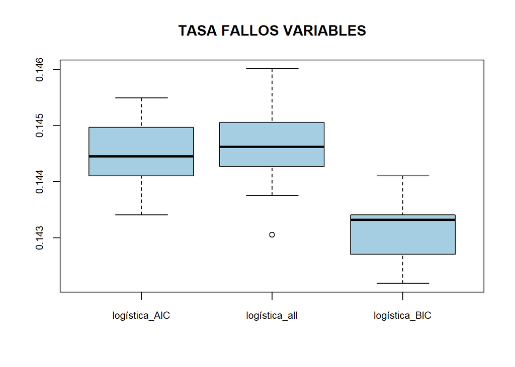

```r
par(cex.axis = 0.8)
boxplot(data = union1, tasa ~ modelo, main = "TASA FALLOS VARIABLES",col=c("#A6CEE3"))
```

El modelo con menor tasa de fallos es el de las variables BIC.

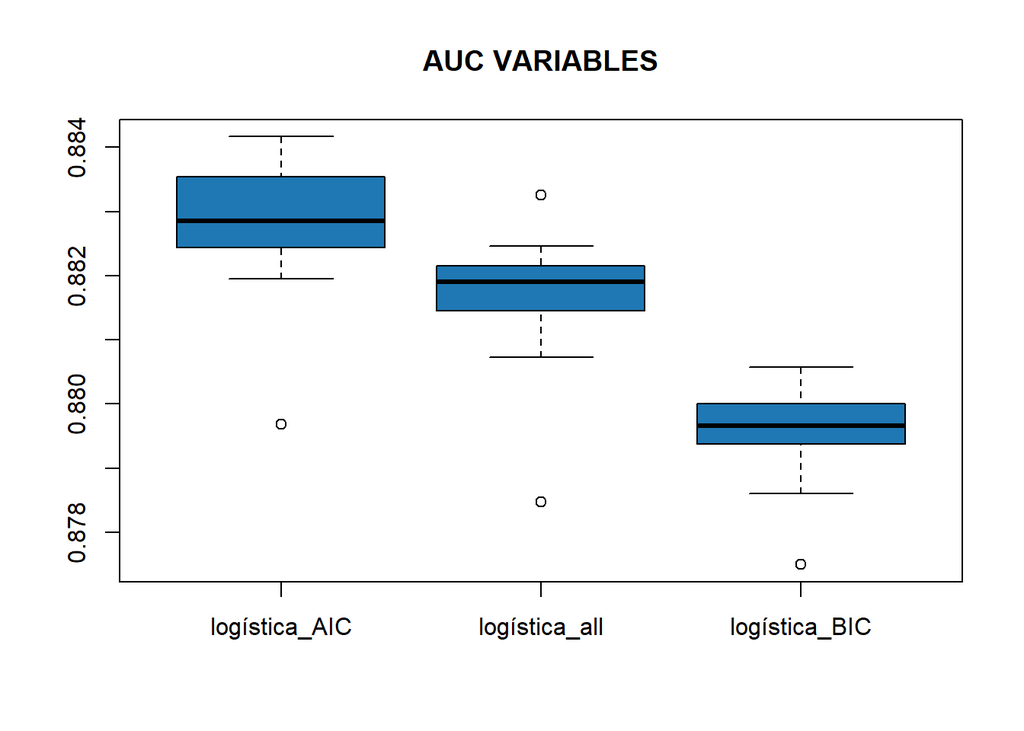

```r
boxplot(data = union1, auc ~ modelo, main = "AUC VARIABLES",col=c("#1F78B4"))
```

Y respecto al AUC el modelo que obtiene mejores resultados es el de las variables AIC.

Nos quedaremos con el conjunto de variables de AIC que incluye variable que también resultaron importantes en la V de Cramer.

Con este conjunto de variables ejecutaremos los diferentes algoritmos de Machine Learning.

## **4.- ALGORITMOS DE APRENDIZAJE AUTOMATICO**

Para obtener el mejor modelo de predicción de la variable Mortalidad se van a utilizar los siguientes algoritmos:

- Regresión logística
- Arboles
- Redes Neuronales
- Bagging
- Random Forest
- Gradient Boosting
- Support Vector Machines (SVM)

Utilizaremos las diferentes funciones proporcionadas por el profesor que utilizan validación cruzada repetida. Se obtiene para los diferentes modelos de cada algoritmo la tasa de fallos y el valor del AUC.

Se grafican en un boxplot y de este modo se selecciona el mejor modelo para cada uno de los algoritmos. Una vez obtenido el mejor modelo se comparará con el mejor modelo de regresión logística. Así podemos ver si alguno de estos algoritmos supera a la logística.

En las siguientes secciones se hace un resumen de las características de los modelos utilizados. No sé ha considerado importante mostrar el código que se podrá consultar en el ANEXO.

### **4.1.- Regresión logística**

Se indican a continuación las características de los modelos utilizados.

| Modelo | Tasa media | AUC media | Semilla | Repeticiones |
| --- | --- | --- | --- | --- |
| logistica1 | 0.1444831 | 0.8829462 | 1234 | 10 |
| logistica2 | 0.1445643 | 0.8828273 | 1234 | 15 |
| logistica3 | 0.1445179 | 0.8829745 | 5678 | 10 |
| logistica4 | 0.1444483 | 0.8829803 | 5678 | 15 |
| logistica5 | 0.1442656 | 0.8828368 | 34567 | 20 |
| **logistica6** | **0.1442743** | **0.8829448** | **34567** | **30** |

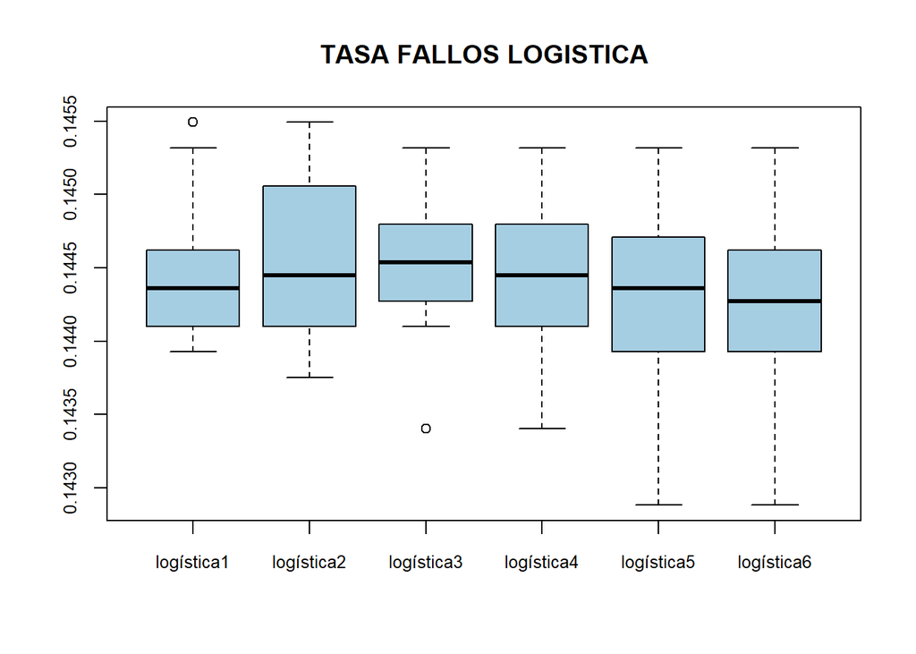

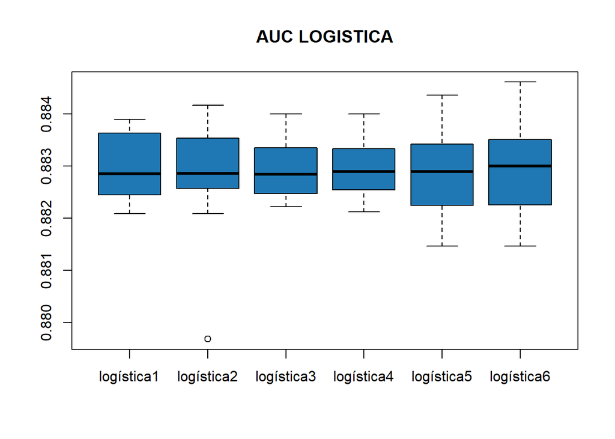

### **4.2.- Árboles**

Los parámetros a tunear de los árboles son:

- minbucket: número de observaciones máximas en el nodo final
- cp: parámetro de corte de penalización por complejidad (cp = 0, máxima complejidad)

Los modelos que se han probado han sido los siguientes:

| Modelo | Tasa media | AUC media | Semilla | Repeticiones | cp | minbucket |
| --- | --- | --- | --- | --- | --- | --- |
| arbol1 | 0.1584813 | 0.8681750 | 1234 | 30 | 0 | 20 |
| arbol2 | 0.1423889 | 0.8235285 | 1234 | 30 | 0.001 | 20 |
| arbol3 | 0.1416638 | 0.8129940 | 1234 | 30 | 0.005 | 30 |
| **arbol4** | **0.1582579** | **0.8687869** | **5678** | **20** | **0** | **20** |
| arbol5 | 0.1427341 | 0.8266223 | 5678 | 20 | 0.001 | 20 |
| arbol6 | 0.1416638 | 0.8122747 | 5678 | 20 | 0.005 | 30 |

Gráficamente vemos que los modelos arbol1 y arbol4 presenta tasa de fallos parecidas

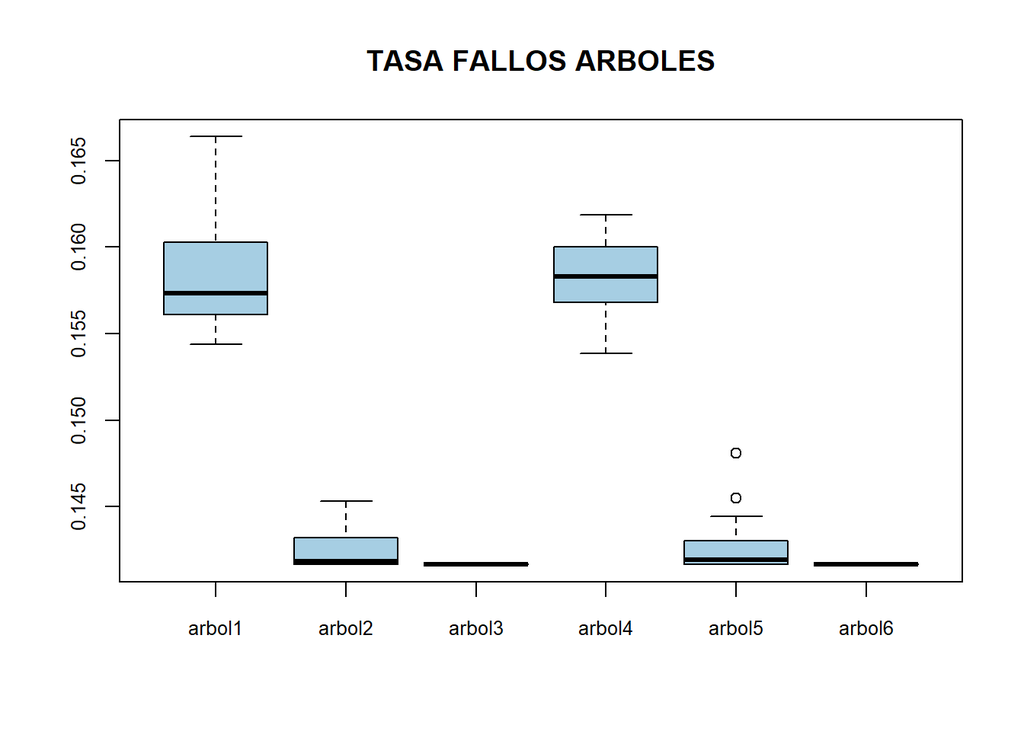

Y también el AUC es similar.

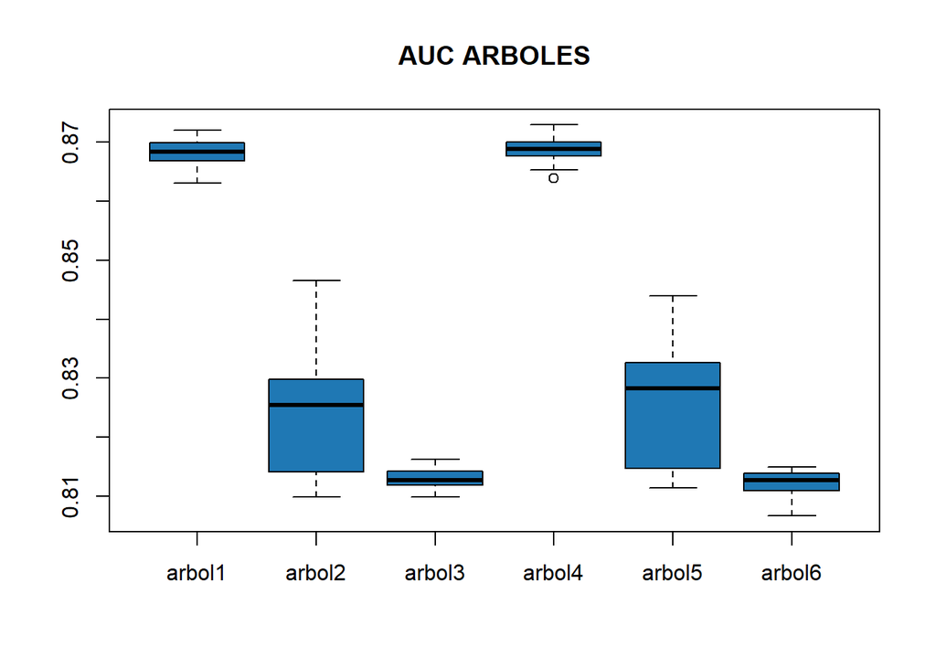

Elegimos el modelo arbol4 por tener ser un poco mayor AUC.  
Se observa que estos modelos tienen peores resultados que la regresión logística.

### **4.3.- Redes Neuronales**

Algunos de los parámetros a tunear en las redes son:

- Size: número de nodos en la capa oculta
- Decay: velocidad de decrecimiento de los pesos

Los modelos que se han probado han sido los siguientes:

[output not shown]

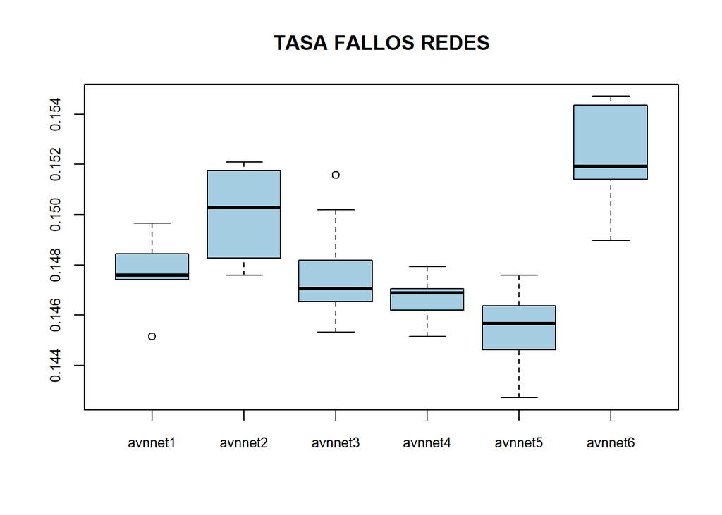

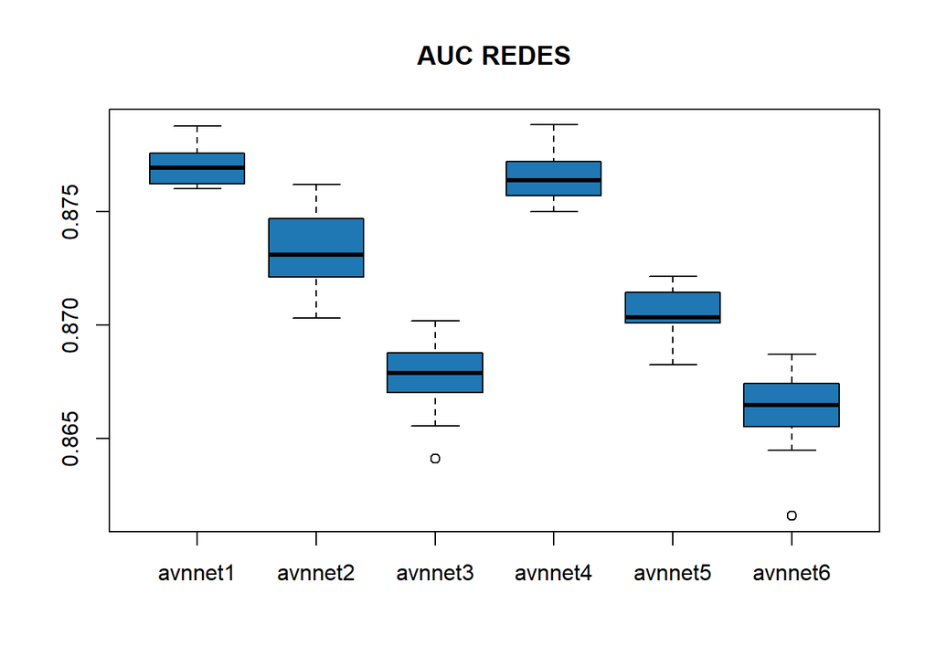

El modelo avnnet4 es el elegido en este caso debido a que tiene alto AUC y su tasa de fallos es baja.

Se observa que estos modelos tienen mejores resultados que los árboles pero siguen siendo peores resultados que la regresión logística.

### **4.4.- Bagging**

Algunos de los parámetros a tunear son:

- mtry: es número total de variables independientes del modelo (12 para nuestro modelo)
- nodesize: tamaño máximo de nodos totales (mide la complejidad)
- ntree: número de árboles o iteraciones
- sampsize: el tamaño de cada muestra
- replace: indica si hay reemplazamiento (TRUE) o no (FALSE)

Los modelos que se han probado han sido los siguientes:

| Modelo | Tasa media | AUC media | Semilla | Nodos | Arboles | Repe | Sampsize |
| --- | --- | --- | --- | --- | --- | --- | --- |
| bagging1 | 0.1419770 | 0.8786311 | 1234 | 10 | 2000 | 5 | 50 |
| bagging2 | 0.1417682 | 0.8795765 | 1234 | 15 | 2500 | 10 | 100 |
| bagging3 | 0.1421946 | 0.8807482 | 1234 | 10 | 2500 | 20 | 150 |
| bagging4 | 0.1420118 | 0.8787219 | 5678 | 10 | 3000 | 5 | 50 |
| **bagging5** | **0.1418552** | **0.8802490** | **5678** | **15** | **4000** | **10** | **150** |
| bagging6 | 0.1416812 | 0.8797063 | 5678 | 20 | 3500 | 20 | 200 |

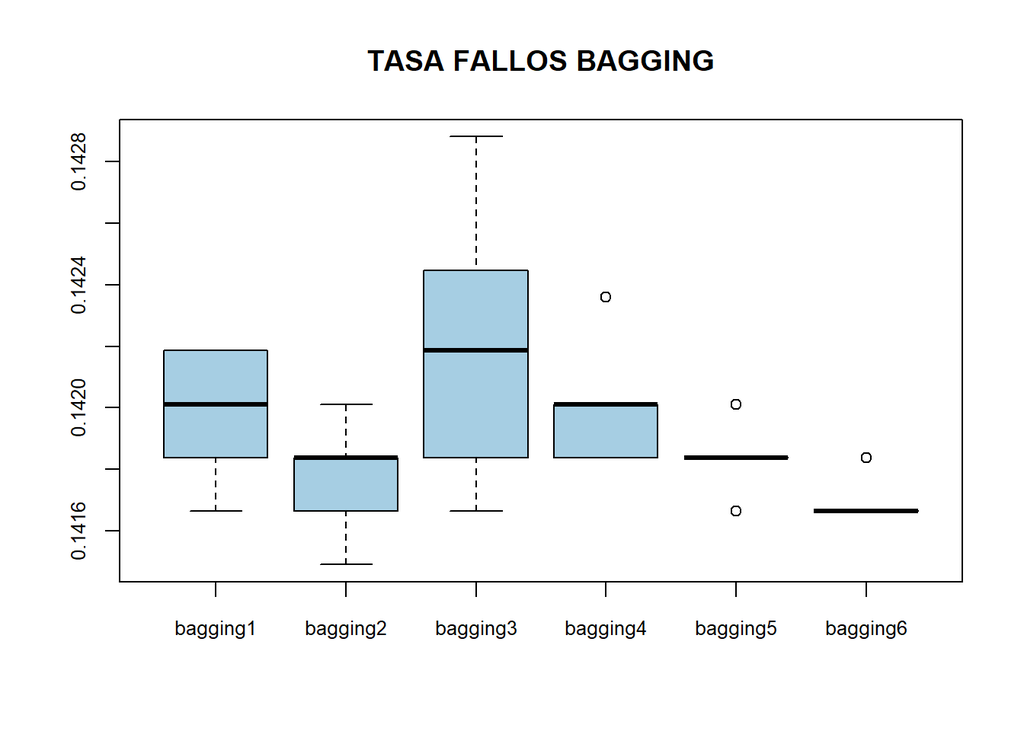

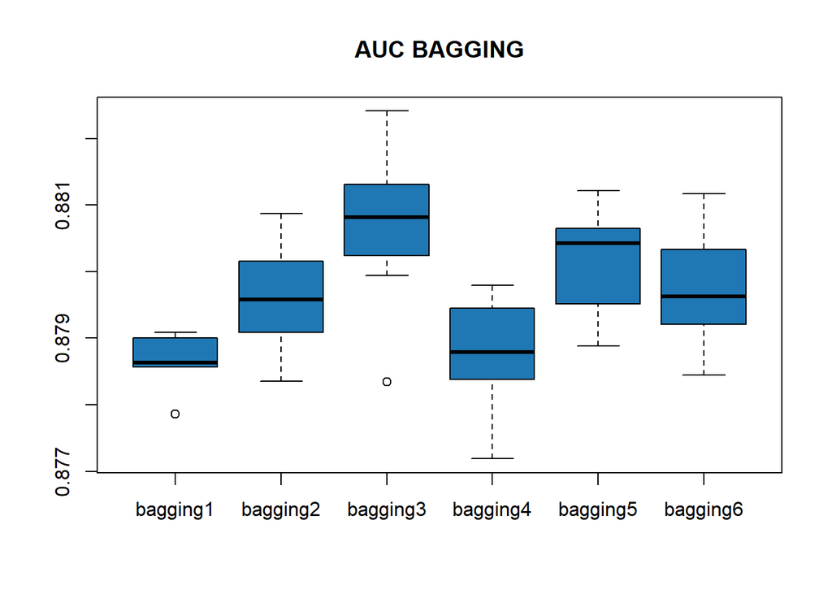

Elegimos el modelo bagging5 que si bien no es el de mayor AUC tampoco es el que menos y además tiene baja tasa de fallos.